# Order Statistics & Data Intake

## Pole Vault Records from Wikipedia

Maybe we plot the density of records?

- what would low density mean?
- what would high density mean?

```r
PVRecordsData <-
  PVrecords %>%
  mutate(Record_m = parse_number(Mark)) %>%
  select(Mark, Record_m)

head(PVRecordsData)
```

[output not shown]

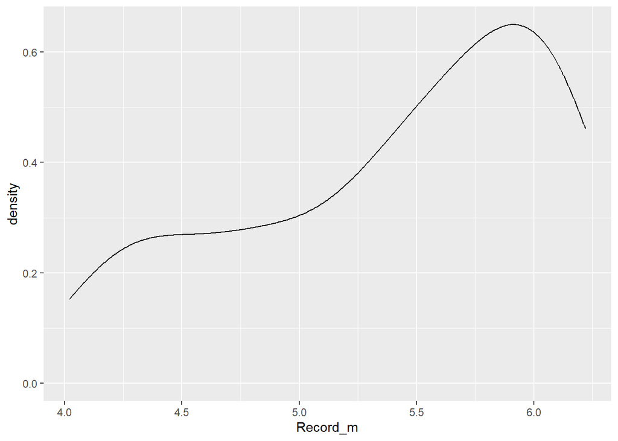

```r
PVRecordsData %>%
  ggplot(aes(x = Record_m)) +
  geom_density()
```

```r
round(PVRecordsData$Record_m) %>%
  table()
```

```
## .
##  4  5  6
## 11 26 41
```

## Penn State Football Receiving Statistics

1. Google Penn State Football Statistics
2. Edit the R code chunk shown to paste `webpage` URL with quotes around it as shown.
3. Execute the code chunk to scrape all HTML tables found on the page into a “list” object in the R environment called `Tables` here
4. Identify a data table from the source (for example, “receiving statistics”) and find it in the list object in your R environment

```
library("rvest")
page <- "http://www.espn.com/college-football/team/stats/_/id/213/penn-state-nittany-lions"

Tables <- page %>%
  read_html(header = TRUE) %>%
  html_nodes(css = "table") %>%
  html_table(fill = TRUE)
```

```
Tables[[1]]
```

## Penn State Football Receiving Statistics

```r
url <- "http://www.espn.com/college-football/team/stats/_/id/213/penn-state-nittany-lions"

PlayerStats <- url %>%
  read_html() %>%
  html_nodes(css = "table") %>%
  html_table(fill = TRUE)
```

```r
# R stores the result as a "list" object, so the double square brackets select an
#    element of the list, and we store it at as a data frame

ReceivingRaw <- PlayerStats[[6]]

# Inspect the Data Table
ReceivingRaw
```

| REC | YDS | AVG | LNG | TD |
| --- | --- | --- | --- | --- |
| 46 | 611 | 13.3 | 58 | 2 |
| 51 | 577 | 11.3 | 34 | 5 |
| 24 | 389 | 16.2 | 88 | 4 |
| 32 | 362 | 11.3 | 67 | 5 |
| 20 | 328 | 16.4 | 48 | 4 |
| 19 | 273 | 14.4 | 48 | 1 |
| 20 | 188 | 9.4 | 45 | 1 |
| 10 | 123 | 12.3 | 38 | 3 |
| 8 | 89 | 11.1 | 20 | 0 |
| 11 | 85 | 7.7 | 22 | 1 |

[output cut: 11 more lines]

```r
# Add player names and remove totals
ReceivingStats <-
  bind_cols(PlayerStats[[5]], PlayerStats[[6]]) %>%
  filter(Name != "Total")

# Inspect FootballStatsClean
ReceivingStats
```

| Name | REC | YDS | AVG | LNG | TD |
| --- | --- | --- | --- | --- | --- |
| Parker Washington WR | 46 | 611 | 13.3 | 58 | 2 |
| Mitchell Tinsley WR | 51 | 577 | 11.3 | 34 | 5 |
| KeAndre Lambert-Smith WR | 24 | 389 | 16.2 | 88 | 4 |
| Brenton Strange TE | 32 | 362 | 11.3 | 67 | 5 |
| Theo Johnson TE | 20 | 328 | 16.4 | 48 | 4 |
| Harrison Wallace III WR | 19 | 273 | 14.4 | 48 | 1 |
| Kaytron Allen RB | 20 | 188 | 9.4 | 45 | 1 |
| Tyler Warren TE | 10 | 123 | 12.3 | 38 | 3 |
| Liam Clifford WR | 8 | 89 | 11.1 | 20 | 0 |
| Nicholas Singleton RB | 11 | 85 | 7.7 | 22 | 1 |

[output cut: 10 more lines]

## Aside: XPath selector

- so far, we have been scraping every table in sight and then hunting through the results for the ones we want.
- you can scrape one specific table with an XPath selector
- some example code is below… basically you only need to change one line
  - use `html_node()` (singular) rather than `html_nodes()` (plural)
  - specify the XPath selector
  - see the help documentation for `html_nodes()` to learn more about the syntax
  - helpful instructions for getting the XPath to an element on a web page using Google Chrome browser: http://www.r-bloggers.com/using-rvest-to-scrape-an-html-table/
- CSS selectors for single table also available through the `selectr` package, which is a port of the python `cssselect` library (see help documentation for `html_nodes()`)

```r
library("rvest")

page_url <- "https://en.wikipedia.org/wiki/Mile_run_world_record_progression"
XPATH <- '//*[@id="mw-content-text"]/div/table'
cssPATH <- '#mw-content-text > div.mw-parser-output > table:nth-child(11)'

table_list_1 <-
  page_url %>%
  read_html() %>%
  html_node(xpath = XPATH) %>%
  html_table(fill = TRUE)

table_list_2 <-
  page_url %>%
  read_html() %>%
  html_node(css = cssPATH) %>%
  html_table(fill = TRUE)

table_list_1
```

| Time | Athlete | Nationality | Date | Venue |
| --- | --- | --- | --- | --- |
| 4:28 | Charles Westhall | United Kingdom | 26 July 1855 | London |
| 4:28 | Thomas Horspool | United Kingdom | 28 September 1857 | Manchester |
| 4:23 | Thomas Horspool | United Kingdom | 12 July 1858 | Manchester |
| 4:221⁄4 | Siah Albison | United Kingdom | 27 October 1860 | Manchester |
| 4:213⁄4 | William Lang | United Kingdom | 11 July 1863 | Manchester |
| 4:201⁄2 | Edward Mills | United Kingdom | 23 April 1864 | Manchester |
| 4:20 | Edward Mills | United Kingdom | 25 June 1864 | Manchester |
| 4:171⁄4 | William Lang | United Kingdom | 19 August 1865 | Manchester |
| 4:171⁄4 | William Richards | United Kingdom | 19 August 1865 | Manchester |
| 4:161⁄5 | William Cummings | United Kingdom | 14 May 1881 | Preston |

[output cut: 1 more lines]

```r
table_list_2
```

| Time | Athlete | Nationality | Date | Venue |
| --- | --- | --- | --- | --- |
| 4:28 | Charles Westhall | United Kingdom | 26 July 1855 | London |
| 4:28 | Thomas Horspool | United Kingdom | 28 September 1857 | Manchester |
| 4:23 | Thomas Horspool | United Kingdom | 12 July 1858 | Manchester |
| 4:221⁄4 | Siah Albison | United Kingdom | 27 October 1860 | Manchester |
| 4:213⁄4 | William Lang | United Kingdom | 11 July 1863 | Manchester |
| 4:201⁄2 | Edward Mills | United Kingdom | 23 April 1864 | Manchester |
| 4:20 | Edward Mills | United Kingdom | 25 June 1864 | Manchester |
| 4:171⁄4 | William Lang | United Kingdom | 19 August 1865 | Manchester |
| 4:171⁄4 | William Richards | United Kingdom | 19 August 1865 | Manchester |
| 4:161⁄5 | William Cummings | United Kingdom | 14 May 1881 | Preston |

[output cut: 1 more lines]

## Assignments

- Reading Quiz Chapters 13 and 16 (due Tuesday July 25 9:59 am)